# Pathogen test & isolation

Biogas lab course 2024

Thomas Klammsteiner, PhD

thomas.klammsteiner@uibk.ac.at

[Department of Microbiology, University of Innsbruck](https://tklammsteiner.github.io)

Sebastian Hupfauf, PhD

sebastian.hupfauf@uibk.ac.at

[Department of Microbiology, University of Innsbruck](https://uibk.ac.at/microbiology)

## Schedule

| 08.11 | 09.11 | 10.11 | 11.11 | 12.11 | 13.11 | 14.11 | 15.11 |
| --- | --- | --- | --- | --- | --- | --- | --- |
| Exam | Gas quantity | Gas quantity | Gas quantity | Gas quantity | Gas quantity | Gas quantity | Gas quantity |
| Gas quantity | Gas quality | Gas quality | Gas quality | Gas quality | Gas quality | Gas quality | Gas quality |
| Gas quality | Plates @4 °C | Plates @4 °C | Sampling | Colony PCR | Sampling | DM weighing | Sampling |
| Sampling | NA | NA | Feeding | Gel electrophoresis | Feeding | DM for C:N | pH/EC |
| Feeding | NA | NA | pH/EC | NanoDrop/Quantus | pH/EC | oDM incubation | FOS/TAC |
| pH/EC | NA | NA | FOS/TAC | PCR clean-up | FOS/TAC | BLAST | NH4/VFA |
| FOS/TAC | NA | NA | DM weighing | Sanger Sequencing | COD | Microscopy | COD |
| DM incubation | NA | NA | DM for C:N | oDM weighing | oDM weighing | Anaerobic fungi | oDM weighing |
| Plating | NA | NA | oDM incubation | DM weighing | DM incubation | NA | DM incubation |
| NA | NA | NA | DM incubation | DM for C:N | NA | NA | Plating |

[output cut: 1 more lines]

## Pathogen test

**?**

**?**

**?**

## Pathogen test

**E. coli**

**Salmonella sp.**

**Listeria sp.**

## Pathogen test

**E. coli**

**Salmonella sp.**

**Listeria sp.**

## Pathogen test

**E. coli**

**Phylum**: Proteobacteria  
**Class**: Gammaproteobacteria  
**Family**: Enterobacteraceae

- Gram-negative, no spores
- Rod-shaped, peritrichous
- Length: 2 µm, Ø: 0.25-1 µm
- Facultatively anaerobic
- Chemoorganotrophic
- Non-pathogenic and pathogenic groups (EHEC, ETEC, etc.)

**Salmonella sp.**

**Phylum**: Proteobacteria  
**Class**: Gammaproteobacteria  
**Family**: Enterobacteraceae

- Gram-negative, no spores
- Rod-shaped, peritrichous
- Length: 2-5 µm, Ø: 0.7-1.5 µm
- Facultatively anaerobic
- Chemoorganotrophic
- Exclusively pathogenic

## Pathogen test

### Chromocult agar

| Test strains | CFU/mL | Colour | Recovery |
| --- | --- | --- | --- |
| *E. coli* ATCC 25922 | 10<sup>3</sup>-10<sup>5</sup> | blue-green | ≥ 70% |
| *Citrobacter freundii* ATCC 8090 | ≥ 10<sup>5</sup> | - | ≤ 0.01% |
| *Enterococcus faecalis* ATCC 19433 | ≥ 10<sup>5</sup> | - | ≤ 0.01% |

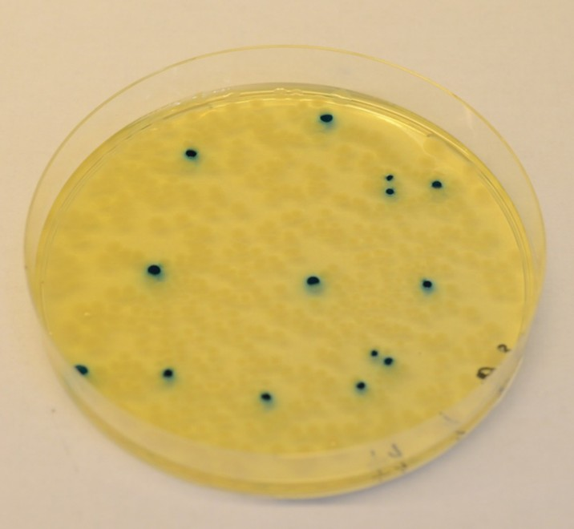

## Pathogen test

### XLT-4 Agar

| Test strains | Growth | Colour |
| --- | --- | --- |
| *Salmonella typhimurium* ATCC 14028 | good/very good | black center |
| *Salmonella enteritidis* ATCC 13076 | good/very good | black center |
| *Salmonella anatum* ATCC 9270 | good/very good | black center |
| *Shigella sonnei* ATCC 11060 | good/very good | colourless |
| *Shigella flexneri* ATCC 12022 | good/very good | colourless |
| *Enterobacter aerogenes* ATCC 13048 | fair/good | yellow |
| *C. freundii* ATCC 8090 | fair/good | yellow |
| *Proteus mirabilis* ATCC 14273 | none/poor | - |
| *E. coli* ATCC 25922 | none/fair | yellow-colourless |

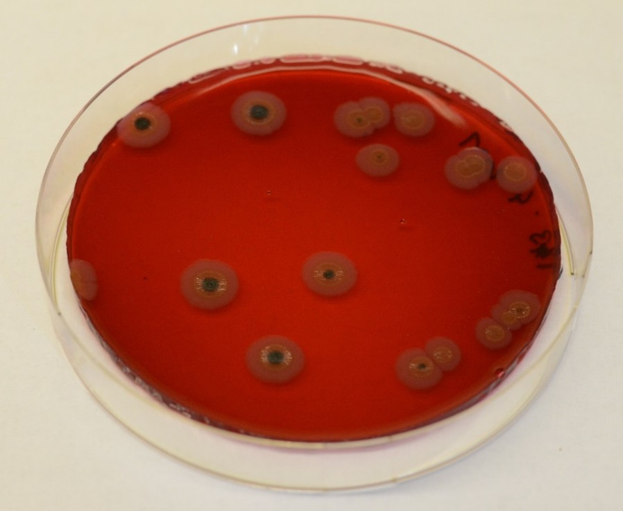

## Master plates

- To isolate morphologically interesting and free-standing colonies from different media
- Colonies are transferred from the original culture medium to the STD agar master plate using sterile pipette tips
- Grid as a guide and for documentation purposes
- Please **do not pick** overlapping or fused colonies!
- Incubate the master plate at **37 °C**

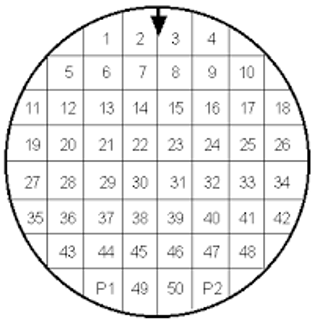

## iChip

- **Problem**  
  Only a fraction (approx. 1–2%) of microorganisms can be cultured
- **Reasons**  
  Growth rate, dependencies, competition, nutrient requirements, communication, …
- **Improvements**  
  Cultivation/isolation in the natural habitat:
  - Ideal environmental conditions (temperature, humidity, pH, etc.)
  - Sufficient nutrient availability
  - Inter- and intraspecific communication possible

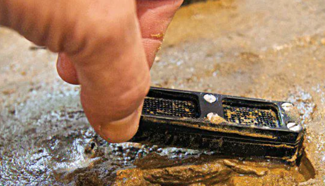

Photo: Slava Epstein

## iChip

[figure not shown]

Photo: 2021 Small World Initiative, INC.